# Assignment #3

Ethan Jantz

10/6/2020

This document is made using [R Markdown](https://rmarkdown.rstudio.com/), a great tool for sharing research in a way that is readable and easily reproducible.

## Assignment 3

Part A:

```
Select two categorical variables.
    Provide relevant descriptive statistics (frequencies, modal response) for these variables and the syntax used to do so.
Select two continuous (ordinal, interval, or ratio) variables.
    Provide relevant descriptive statistics (mean, median, measures of dispersion).
```

Part B:

```
Choose a dichotomous categorical variable (or simplify categorical variables with more than two categories).
    First, test whether the proportion of respondents giving a particular response is significantly different from 50%.
    Second, test whether the proportion of respondents giving the response is significantly different from 25%.
Next, choose a continuous (ordinal, interval, or ratio) variable.
    First test whether the mean of the variable is significantly different from zero (0).
    Second, test whether the mean of the variable is significantly different from one (1).
Provide all R code and text to accompany and describe what you did and the results.
```

```r
knitr::opts_chunk$set(echo = TRUE, message = FALSE, warning = FALSE) # R Markdown options
library(psych); library(ltm) # psych for describe(), ltm for cronbach.alpha()
library(tidyverse); library(cowplot) # Cowplot for placing plots side by side
library(urbnmapr) # For making the map that visualizes frequencies
library(rmarkdown) # For accessing the functions used to display tables
library(haven) # For reading ANES2016.dta file
library(here) # For easier file referencing. See documentation at https://here.r-lib.org/

anes <- haven::read_dta("ANES2016.dta") # Reading in the data

states_sf <- get_urbn_map(map = "states", sf = TRUE) # Read in spatial data
```

## Part A

Here I am selecting the data for both part A and B from the ANES dataset.

```r
selected <-
  anes %>%
  select(
    "State" = V161015b,
    "Pres_Vote" = V161027,
    "Dem" = V161086,
    "Rep" = V161087
    )
```

In a previous version of this I filtered the data by cutting out non-responses from each question, but that narrowed the data down to a very small number. In this assignment I will only filter the data when a variable is being manipulated or analyzed to provide larger sample sizes.

### Categorical Variables

| Variable Code (dta) | Variable Name (code book) | Categories |
| --- | --- | --- |
| **V161015b** | Registration state (all registrations) | All 50 states + DC and PR |
| **V161027** | For whom did R vote for President | Hillary Clinton, Donald Trump, Gary Johnson, Jill Stein, Other |

#### Registration

For categorical variables we can visualize the descriptive statistics through bar plots. Because one of the variables is a spatial category we can also use mapping! This is a heat map of responses by state.

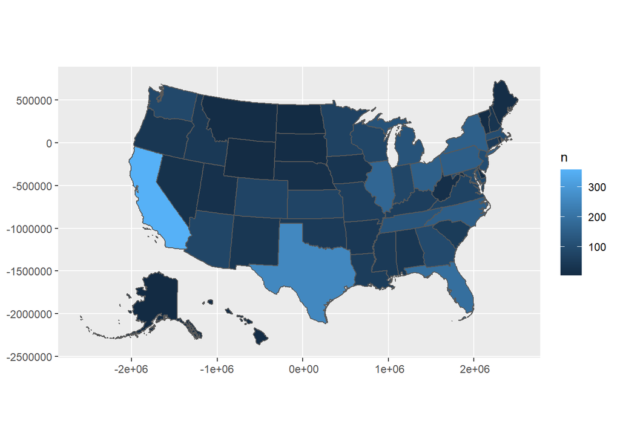

```r
selected %>%
  filter(
    State > 0
  ) %>%
  select(State) %>%
  mutate(
    State = gsub("[^0-9]","",as_factor(State)) %>%
      ifelse(nchar(.) < 2, paste0("0", .), .)# gsub replaces characters, in this case I'm removing all of the non-digit characters in the labels (as_factor()) of the State variable.
    # This leaves the numeric value of the state (look up "FIPS code" to understand why they go all the way to 56) to match with the states_sf object I created earlier.
    # The ifelse statement adds a 0 to the value if it's a single digit number so I can match them down the line
    # The periods are referencing the "State" variable, nchar() returns the length of a string
    ) %>%
  group_by(State) %>% # This is used to create summary tables in tidyverse
  count() %>% # This is a type of summary table, the generic form is summarize()
  left_join(states_sf, by = c("State" = "state_fips")) %>% # This joins the States to the states_sf table by the named columns
  ggplot(aes(geometry = geometry)) +
  geom_sf(aes(fill = n))
```

And here is a bar plot with count labels to better display the frequencies. **The modal responding state was California with 357 responses.**

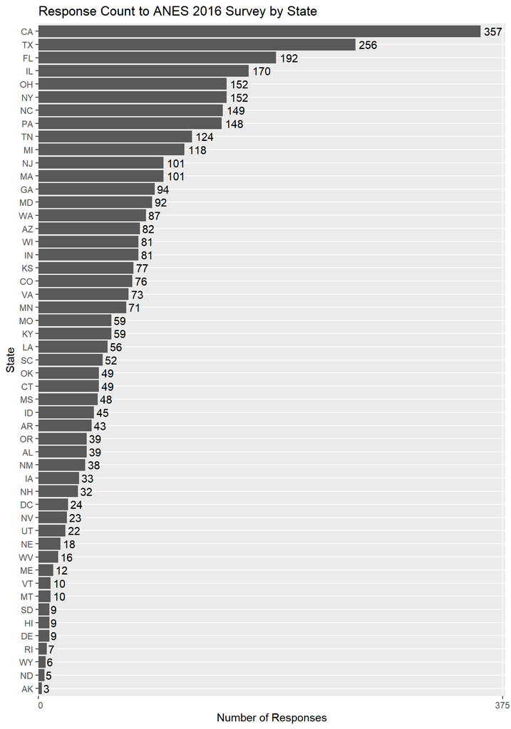

```r
# I set the fig.height in this chunk's header, that makes the ggplot itself larger when it's printed on the file
# This makes it so the x axis labels aren't so bunched up
selected %>%
  filter(
    State > 0
  ) %>%
  select(State) %>%
  mutate(
    State = gsub("[^0-9]","",as_factor(State)) %>%
      ifelse(nchar(.) < 2, paste0("0", .), .)
    ) %>%
  group_by(State) %>%
  count() %>%
  left_join(states_sf, by = c("State" = "state_fips")) %>%
  ggplot(aes(x = reorder(state_abbv, n), y = n)) +
  geom_col() +
  geom_text(aes(label = n), hjust = -.2) +
  scale_y_discrete(limits = c(0, 375), expand = c(0,0,0,20)) +
  labs(x = "State", y = "Number of Responses", title = "Response Count to ANES 2016 Survey by State") +
  coord_flip()
```

It would be interesting to do this in terms of responses per capita or something, but I’m not going to do that in this assignment. Two interesting things to note here are 1.) Puerto Rico was not included in this survey and 2.) DC had more responses than several states.

#### Presidential Candidate

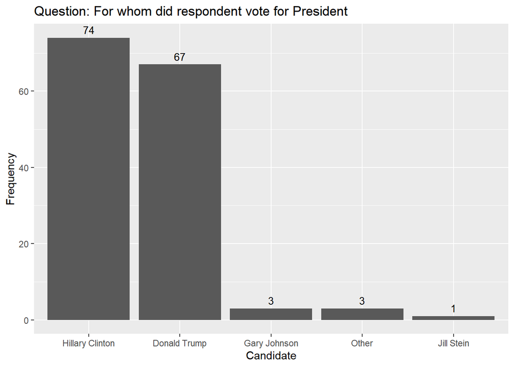

```r
selected %>%
  filter(
    Pres_Vote > 0
  ) %>%
  select(Pres_Vote) %>%
  mutate(
    Candidate = case_when(
      . == 1 ~ "Hillary Clinton",
      . == 2 ~ "Donald Trump",
      . == 3 ~ "Gary Johnson",
      . == 4 ~ "Jill Stein",
      . == 5 ~ "Other"
    )
  ) %>%
  ggplot(aes(x = forcats::fct_infreq(Candidate))) + # fct_infreq reorders the bars highest-lowest count
  geom_bar(stat = "count") +
  stat_count(geom = "text", size = 3.5, aes(label = ..count..), vjust = -.5) +
  labs(x = "Candidate", y = "Frequency", title = "Question: For whom did respondent vote for President")
```

I think that because this is a Pre-election survey, among other limitations, a very small number of respondents provided an answer to this question. But regardless, **the modal response was Hillary Clinton with 74 votes.**

### Continuous Variables

| Variable Code (dta) | Variable Name (code book) | Range |
| --- | --- | --- |
| **V161086** | Feeling Thermometer: Democratic Presidential Candidate | 0 - 100 |
| **V161087** | Feeling Thermometer: Republican Presidential Candidate | 0 - 100 |

#### Feeling Thermometers

```r
Dem <- selected %>%
  filter(
    Dem >= 0
  ) %>%
  select(Dem)

Rep <- selected %>%
  filter(
    Rep >= 0
  ) %>%
  select(Rep)
```

With continuous data we have a couple of ways to visualize the descriptive statistics. You can use a histogram to see frequencies:

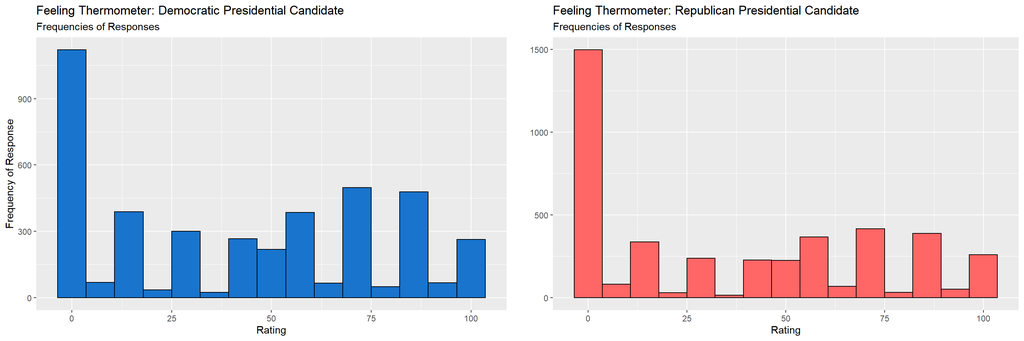

```r
demHist <- ggplot(Dem) +
  geom_histogram(aes(x = Dem), fill = "dodgerblue3", color = "black", bins = 15) +
  labs(x = "Rating", y = "Frequency of Response",
       title = "Feeling Thermometer: Democratic Presidential Candidate",
       subtitle = "Frequencies of Responses")

repHist <- ggplot(Rep) +
  geom_histogram(aes(x = Rep), fill = "#ff6666", color = "black", bins = 15) +
  labs(x = "Rating", y = "",
       title = "Feeling Thermometer: Republican Presidential Candidate",
       subtitle = "Frequencies of Responses")

plot_grid(demHist, repHist)
```

Or you can use a boxplot to visualize the median and quantiles. I’ve also added a dashed line to visualize the mean:

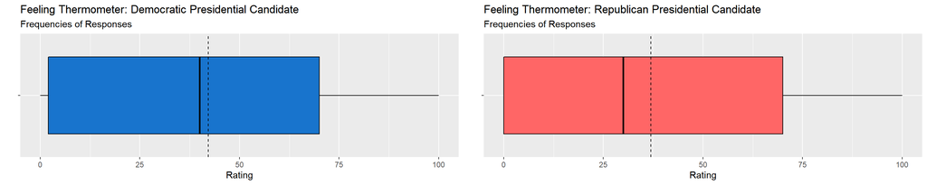

```r
demBox <- ggplot(Dem) +
  geom_boxplot(aes(x = Dem, y = ""), fill = "dodgerblue3", color = "black") +
  geom_vline(xintercept = mean(unlist(Dem)), linetype = "dashed") + # You have to unlist the Dem object because of the way haven handles dta files
  labs(x = "Rating", y = "",
       title = "Feeling Thermometer: Democratic Presidential Candidate",
       subtitle = "Frequencies of Responses")

repBox <- ggplot(Rep) +
  geom_boxplot(aes(x = Rep, y = ""), fill = "#ff6666", color = "black") +
  geom_vline(xintercept = mean(unlist(Rep)), linetype = "dashed") +
  labs(x = "Rating", y = "",
       title = "Feeling Thermometer: Republican Presidential Candidate",
       subtitle = "Frequencies of Responses")

plot_grid(demBox, repBox)
```

Of course, neither of these visualizations cover all of the descriptive statistics. So here is the table of selected descriptive stats:

```r
demDesc <- describe(unlist(Dem)) %>%
  select(n, mean, median, min, max, range, sd)

repDesc <- describe(unlist(Rep)) %>%
  select(n, mean, median, min, max, range, sd)

Desc <- rbind(demDesc, repDesc)

rownames(Desc) <- c("Dem", "Rep")

paged_table(Desc)
```

|  | n | mean | median | min | max | range | sd |
| --- | --- | --- | --- | --- | --- | --- | --- |
| Dem | 4232 | 42.14485 | 40 | 0 | 100 | 100 | 34.22870 |
| Rep | 4229 | 36.95744 | 30 | 0 | 100 | 100 | 34.91161 |

## Part B

### Categorical Variable

I’m going to create a dichotomous variable that indicates whether the respondent voted for Donald Trump

```r
Pres_Vote <- selected %>%
  filter(
    Pres_Vote > 0
  ) %>%
  select(Pres_Vote) %>%
  mutate(
    Pres_Vote = ifelse(Pres_Vote == 2, 1, 0)
  )
```

Then, I’m going to run a binomial test to see if the percentage of respondents that voted for Trump is significantly different from 50%

```r
binom.test(sum(Pres_Vote$Pres_Vote), dim(Pres_Vote)[1], alternative = "two.sided", p = .5)
```

```
##
##  Exact binomial test
##
## data:  sum(Pres_Vote$Pres_Vote) and dim(Pres_Vote)[1]
## number of successes = 67, number of trials = 148, p-value = 0.2852
## alternative hypothesis: true probability of success is not equal to 0.5
## 95 percent confidence interval:
##  0.3708119 0.5365250
## sample estimates:
## probability of success
##              0.4527027
```

It looks like it is not significantly different, with a p-value of 0.28. So what about 25%?

```r
binom.test(sum(Pres_Vote$Pres_Vote), dim(Pres_Vote)[1], alternative = "two.sided", p = .25)
```

```
##
##  Exact binomial test
##
## data:  sum(Pres_Vote$Pres_Vote) and dim(Pres_Vote)[1]
## number of successes = 67, number of trials = 148, p-value = 9.943e-08
## alternative hypothesis: true probability of success is not equal to 0.25
## 95 percent confidence interval:
##  0.3708119 0.5365250
## sample estimates:
## probability of success
##              0.4527027
```

This proportion **is** significantly different from 25%, with a p-value < .001.

### Continuous Variable

I’m going to select the Donald Trump Feeling Thermometer for this exercise. I’ll transform the values to be between 0 and 1 by dividing them by 100, then I will test if the mean is significantly different from 0.

```r
Rep <- Rep / 100

t.test(Rep, conf.level = .95)
```

```
##
##  One Sample t-test
##
## data:  Rep
## t = 68.842, df = 4228, p-value < 2.2e-16
## alternative hypothesis: true mean is not equal to 0
## 95 percent confidence interval:
##  0.3590493 0.3800994
## sample estimates:
## mean of x
## 0.3695744
```

With a p-value < .001 we can confidently say that the mean of the ratings of Donald Trump was significantly different from 0. Now let’s perform the same test to see if the mean is significantly different from 1.

```r
Rep <- Rep / 100

t.test(Rep, mu = 1, conf.level = .95)
```

```
##
##  One Sample t-test
##
## data:  Rep
## t = -18558, df = 4228, p-value < 2.2e-16
## alternative hypothesis: true mean is not equal to 1
## 95 percent confidence interval:
##  0.003590493 0.003800994
## sample estimates:
##   mean of x
## 0.003695744
```

And with another p-value < .001 we can confidently say that the mean of the ratings of Donald Trump was significantly different from 1.